# B60_Reflections

| Abuzer Yakaryilmaz \| April 28, 2019 (updated) |
| --- |
| This cell contains some macros. If there is a problem with displaying mathematical formulas, please run this cell to load these macros. |

$ \newcommand{\bra}[1]{\langle #1|} $ $ \newcommand{\ket}[1]{|#1\rangle} $ $ \newcommand{\braket}[2]{\langle #1|#2\rangle} $ $ \newcommand{\dot}[2]{ #1 \cdot #2} $ $ \newcommand{\biginner}[2]{\left\langle #1,#2\right\rangle} $ $ \newcommand{\mymatrix}[2]{\left( \begin{array}{#1} #2\end{array} \right)} $ $ \newcommand{\myvector}[1]{\mymatrix{c}{#1}} $ $ \newcommand{\myrvector}[1]{\mymatrix{r}{#1}} $ $ \newcommand{\mypar}[1]{\left( #1 \right)} $ $ \newcommand{\mybigpar}[1]{ \Big( #1 \Big)} $ $ \newcommand{\sqrttwo}{\frac{1}{\sqrt{2}}} $ $ \newcommand{\dsqrttwo}{\dfrac{1}{\sqrt{2}}} $ $ \newcommand{\onehalf}{\frac{1}{2}} $ $ \newcommand{\donehalf}{\dfrac{1}{2}} $ $ \newcommand{\hadamard}{ \mymatrix{rr}{ \sqrttwo & \sqrttwo \\ \sqrttwo & -\sqrttwo }} $ $ \newcommand{\vzero}{\myvector{1\\0}} $ $ \newcommand{\vone}{\myvector{0\\1}} $ $ \newcommand{\vhadamardzero}{\myvector{ \sqrttwo \\ \sqrttwo } } $ $ \newcommand{\vhadamardone}{ \myrvector{ \sqrttwo \\ -\sqrttwo } } $ $ \newcommand{\myarray}[2]{ \begin{array}{#1}#2\end{array}} $ $ \newcommand{\X}{ \mymatrix{cc}{0 & 1 \\ 1 & 0} } $ $ \newcommand{\Z}{ \mymatrix{rr}{1 & 0 \\ 0 & -1} } $ $ \newcommand{\Htwo}{ \mymatrix{rrrr}{ \frac{1}{2} & \frac{1}{2} & \frac{1}{2} & \frac{1}{2} \\ \frac{1}{2} & -\frac{1}{2} & \frac{1}{2} & -\frac{1}{2} \\ \frac{1}{2} & \frac{1}{2} & -\frac{1}{2} & -\frac{1}{2} \\ \frac{1}{2} & -\frac{1}{2} & -\frac{1}{2} & \frac{1}{2} } } $ $ \newcommand{\CNOT}{ \mymatrix{cccc}{1 & 0 & 0 & 0 \\ 0 & 1 & 0 & 0 \\ 0 & 0 & 0 & 1 \\ 0 & 0 & 1 & 0} } $ $ \newcommand{\norm}[1]{ \left\lVert #1 \right\rVert } $

## Reflections

| *We use certain tools from python library "**matplotlib.pyplot**" for drawing. Check the notebook "Python: Drawing" for the list of these tools.* |
| --- |

We start with drawing the quantum states $ \ket{0} $ and $ \ket{+} = \myvector{ \frac{1}{\sqrt{2}} \\ \frac{1}{\sqrt{2}} } $.

Our predefined function "draw_qubit()" draws a figure, the origin, the axes, the unit circle, and base quantum states.  
Our predefined function "draw_quantum_state(x,y,name)" draws an arrow from (0,0) to (x,y) and associates it with name.  
We include our predefined functions with the following line of code:

```
%run qlatvia.py
```

```python
%run qlatvia.py

draw_qubit()

sqrttwo=2**0.5

draw_quantum_state(1,0,"")

draw_quantum_state(1/sqrttwo,1/sqrttwo,"|+>")

# drawing the angle with |0>-axis
from matplotlib.pyplot import gca, text
from matplotlib.patches import Arc
gca().add_patch( Arc((0,0),0.4,0.4,angle=0,theta1=0,theta2=45) )
text(0.08,0.05,'.',fontsize=30)
text(0.21,0.09,'\u03C0/4')
```

[output not shown]

### Task 1 (Discussion)

Suppose that we start in state $ \ket{0} $ and then obtain state $\ket{+}$ after applying a quantum operator.

If we apply the same operator to state $ \ket{+} $, what can be the new quantum state?

Here are eight candidates:

$$ \myarray{|c|c|c|c|}{ \hline A & \ket{0} = \vzero & E & \ket{+} = \myrvector{\sqrttwo \\ \sqrttwo} \\ \hline B & \ket{1} = \vone & F & \ket{-} = \myrvector{\sqrttwo \\ -\sqrttwo} \\ \hline C & -\ket{0} = \myrvector{-1 \\ 0} & G & -\ket{+} = \myrvector{-\sqrttwo \\ -\sqrttwo} \\ \hline D & -\ket{1} = \myrvector{0 \\ -1} & H & -\ket{-} = \myrvector{-\sqrttwo \\ \sqrttwo} \\ \hline } $$

### Hadamard operator

Can this operator be Hadamard?

Remember the Hadamard operator ($H$):

$$ H = \hadamard . $$

$ H \ket{0} = \hadamard \vzero = \vhadamardzero = \ket{+} $.

$ H \ket{+} = \hadamard \vhadamardzero = \vzero = \ket{0} $.

### Task 2

Verify that Hadamard operator maps the states on the same row to each other.

$$ \myarray{|c|c|c|c|}{ \hline A & \ket{0} = \vzero & E & \ket{+} = \myrvector{\sqrttwo \\ \sqrttwo} \\ \hline B & \ket{1} = \vone & F & \ket{-} = \myrvector{\sqrttwo \\ -\sqrttwo} \\ \hline C & -\ket{0} = \myrvector{-1 \\ 0} & G & -\ket{+} = \myrvector{-\sqrttwo \\ -\sqrttwo} \\ \hline D & -\ket{1} = \myrvector{0 \\ -1} & H & -\ket{-} = \myrvector{-\sqrttwo \\ \sqrttwo} \\ \hline } $$

### Hadamard - geometrical interpretation

Hadamard operator is a reflection and its line of reflection is represented below.

It is the line obtained by rotating $x$-axis with $ \frac{\pi}{8} $ radians in counter-clockwise direction.

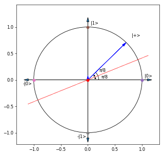

```python
%run qlatvia.py

draw_qubit()

sqrttwo=2**0.5

draw_quantum_state(0,0,"")

draw_quantum_state(1/sqrttwo,1/sqrttwo,"|+>")

# line of reflection for Hadamard
from matplotlib.pyplot import arrow
arrow(-1.109,-0.459,2.218,0.918,linestyle='dotted',color='red')

# drawing the angle with |0>-axis
from matplotlib.pyplot import gca, text
from matplotlib.patches import Arc
gca().add_patch( Arc((0,0),0.4,0.4,angle=0,theta1=0,theta2=22.5) )
text(0.09,0.015,'.',fontsize=30)
text(0.25,0.03,'\u03C0/8')
gca().add_patch( Arc((0,0),0.4,0.4,angle=0,theta1=22.5,theta2=45) )
text(0.075,0.065,'.',fontsize=30)
text(0.21,0.16,'\u03C0/8')
```

### Task 3

Visually verify that Hadamard operator reflects the states on the same row to each other.

For the second, third, and fourth row, draw the line of reflection for Hadamard operator and the states.

$$ \myarray{|c|c|c|c|}{ \hline A & \ket{0} = \vzero & E & \ket{+} = \myrvector{\sqrttwo \\ \sqrttwo} \\ \hline B & \ket{1} = \vone & F & \ket{-} = \myrvector{\sqrttwo \\ -\sqrttwo} \\ \hline C & -\ket{0} = \myrvector{-1 \\ 0} & G & -\ket{+} = \myrvector{-\sqrttwo \\ -\sqrttwo} \\ \hline D & -\ket{1} = \myrvector{0 \\ -1} & H & -\ket{-} = \myrvector{-\sqrttwo \\ \sqrttwo} \\ \hline } $$

Then, randomly create a quantum state and multiply it with Hadamard to find its reflection.

Draw both states.

Repeat the task for a few times.

**The second row**

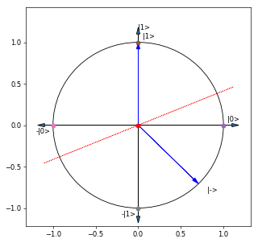

```python
%run qlatvia.py

draw_qubit()

# line of reflection for Hadamard
from matplotlib.pyplot import arrow
arrow(-1.109,-0.459,2.218,0.918,linestyle='dotted',color='red')

#
# your code is here
#

# visually draw the reflections
# second draw

sqrttwo=2**0.5

draw_quantum_state(0,1,"|1>")

draw_quantum_state(1/sqrttwo,-1/sqrttwo,"|->")
```

**The third row**

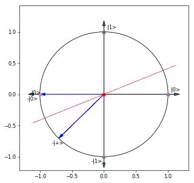

```python
%run qlatvia.py

draw_qubit()

# line of reflection for Hadamard
from matplotlib.pyplot import arrow
arrow(-1.109,-0.459,2.218,0.918,linestyle='dotted',color='red')

#
# your code is here
#
sqrttwo=2**0.5

draw_quantum_state(-1,0,"-|0>")

draw_quantum_state(-1/sqrttwo,-1/sqrttwo,"-|+>")
```

**The fourth row**

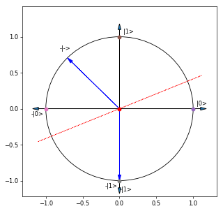

```python
%run qlatvia.py

draw_qubit()

# line of reflection for Hadamard
from matplotlib.pyplot import arrow
arrow(-1.109,-0.459,2.218,0.918,linestyle='dotted',color='red')

#
# your code is here
#
sqrttwo=2**0.5

draw_quantum_state(0,-1,"-|1>")

draw_quantum_state(-1/sqrttwo,1/sqrttwo,"-|->")
```

**Random quantum states**

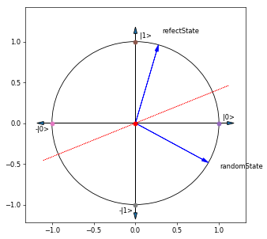

```python
%run qlatvia.py

draw_qubit()

# line of reflection for Hadamard
from matplotlib.pyplot import arrow
arrow(-1.109,-0.459,2.218,0.918,linestyle='dotted',color='red')

#
# your code is here
#

# create a random quantum state
random_state = random_quantum_state2()

# draw random
draw_quantum_state(random_state[0],random_state[1],"randomState")

# apply hadamard
sqrttwo=2**0.5
next_state = [random_state[0] * (1/sqrttwo) + random_state[1] * (1/sqrttwo), random_state[0] * (1/sqrttwo) + random_state[1] * -(1/sqrttwo)]
# draw the state
draw_quantum_state(next_state[0],next_state[1],"refectState")
```

click for our solution

### Task 4

Find the matrix representing the reflection over $x$-axis.

Randomly create a quantum state and multiply it with this matrix to find its reflection over $x$-axis.

Draw both states.

Repeat the task for a few times.

```python
%run qlatvia.py

draw_qubit()

#
# your code is here
#
random_state = random_quantum_state2()

# draw random
draw_quantum_state(random_state[0],random_state[1],"randomState")

# find the reflection to x-axis
# apply hadamard
sqrttwo=2**0.5
next_state = [random_state[0] * (1/sqrttwo) + random_state[1] * (1/sqrttwo), random_state[0] * (1/sqrttwo) + random_state[1] * -(1/sqrttwo)]
# draw the state
draw_quantum_state(next_state[0],next_state[1],"refectState")
```

[output not shown]

click for our solution

### Task 5

Find the matrix for the reflection over $y$-axis.

### Task 6

Find the matrix representing the reflection over the line $y=x$.

*Hint:* Think about the reflections of the points $ \myrvector{0 \\ 1} $, $ \myrvector{-1 \\ 0} $, and $ \myrvector{-\sqrttwo \\ \sqrttwo} $ over the line $y=x$.

Randomly create a quantum state and multiply it with this matrix to find its reflection over the line $y = x$.

Draw both states.

Repeat the task for a few times.

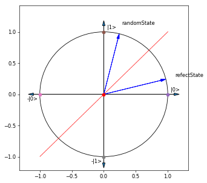

```python
%run qlatvia.py

draw_qubit()

# the line y=x
from matplotlib.pyplot import arrow
arrow(-1,-1,2,2,linestyle='dotted',color='red')

#
# your code is here
#
random_state = random_quantum_state2()

# draw random
draw_quantum_state(random_state[0],random_state[1],"randomState")

# find the reflection to x-axis
# apply hadamard
sqrttwo=2**0.5
next_state = [random_state[0] * 0 + random_state[1] * 1, random_state[0] * 1 + random_state[1] * 0]
# draw the state
# not operator -> switches x and y
draw_quantum_state(next_state[0],next_state[1],"refectState")
```

click for our solution

### Reflection Operators

As we have observed, the following operators are reflections on the unit circle.

**Z operator:** $ Z = \mymatrix{rr}{ 1 & 0 \\ 0 & -1 } $. The line of reflection is $x$-axis.

**NOT operator:** $ X = \mymatrix{rr}{ 0 & 1 \\ 1 & 0 } $. The line of reflection is $y=x$.

**Hadamard operator:** $ H = \hadamard $. The line of reflection is $y= \frac{\sin(\pi/8)}{\cos(\pi/8)} x$.

It is the line passing through the origin making an angle $ \pi/8 $ radians with $x$-axis.

**Arbitrary reflection operator:** Let $ \theta $ be the angle of the line of reflection. Then, the martix form of reflection is represented as follows:

$$ Ref(\theta) = \mymatrix{rr}{ \cos(2\theta) & \sin(2\theta) \\ \sin(2\theta) & -\cos(2\theta) } . $$

### Task 7 (Extra)

Randomly pick the angle $\theta$.

Draw the line of reflection with unit circle.

Contruct the corresponding reflection matrix.

Randomly create a quantum state and multiply it with this matrix to find its reflection.

Draw both states.

Repeat the task for a few times.

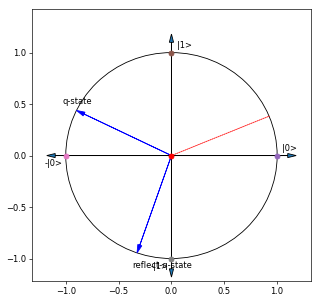

```python
%run qlatvia.py

draw_qubit()

#
# your code is here
#
# line of reflection
from matplotlib.pyplot import arrow
#arrow(x,y,dx,dy,linestyle='dotted',color='red')
#
#
# draw_quantum_state(x,y,"name")


import numpy as np
import math
# method for reflection matrix
def get_reflection_matrix(theta):
    reflect_matrix = np.array([[math.cos(2 * theta), math.sin(2 * theta)],[math.sin(2 * theta), -math.cos(2 * theta)]])
    return reflect_matrix

# obtain a random quantum state
random_quantum_state = np.array(random_quantum_state2())
draw_quantum_state(random_quantum_state[0],random_quantum_state[1],"q-state")
theta = math.pi/8
reflected_state = np.matmul(get_reflection_matrix(theta), random_quantum_state)
draw_quantum_state(reflected_state[0],reflected_state[1],"reflect-q-state")

arrow(0,0,math.cos(theta),math.sin(theta),linestyle='dotted',color='red')
```